### Transform the data

Remember that the principal components are linear combinations of the original variables. We can calculate the new data matrix `y`by multiplying the original data matrix `x` by the rotation matrix with eigenvectors as columns. The `predict` function does this, but centers the original data first. Let’s do it manually.

```r
head(x)
```

```
##   Sepal.Length Sepal.Width Petal.Length Petal.Width
## 1          5.1         3.5          1.4         0.2
## 2          4.9         3.0          1.4         0.2
## 3          4.7         3.2          1.3         0.2
## 4          4.6         3.1          1.5         0.2
## 5          5.0         3.6          1.4         0.2
## 6          5.4         3.9          1.7         0.4
```

```r
# center the data
means <- colMeans(x)
print(means)
```

```
## Sepal.Length  Sepal.Width Petal.Length  Petal.Width
##     5.843333     3.057333     3.758000     1.199333
```

```r
x_centered <- x
for (i in 1:nrow(x)) {
  x_centered[i, ] <- x[i, ] - means
}
head(x_centered)
```

```
##   Sepal.Length Sepal.Width Petal.Length Petal.Width
## 1   -0.7433333  0.44266667       -2.358  -0.9993333
## 2   -0.9433333 -0.05733333       -2.358  -0.9993333
## 3   -1.1433333  0.14266667       -2.458  -0.9993333
## 4   -1.2433333  0.04266667       -2.258  -0.9993333
## 5   -0.8433333  0.54266667       -2.358  -0.9993333
## 6   -0.4433333  0.84266667       -2.058  -0.7993333
```

```r
print(round(colMeans(x_centered), 3))
```

```
## Sepal.Length  Sepal.Width Petal.Length  Petal.Width
##            0            0            0            0
```

```r
y <- as.matrix(x_centered) %*% eig$vectors
head(y)
```

```
##           [,1]       [,2]        [,3]         [,4]
## [1,] -2.684126 -0.3193972  0.02791483  0.002262437
## [2,] -2.714142  0.1770012  0.21046427  0.099026550
## [3,] -2.888991  0.1449494 -0.01790026  0.019968390
## [4,] -2.745343  0.3182990 -0.03155937 -0.075575817
## [5,] -2.728717 -0.3267545 -0.09007924 -0.061258593
## [6,] -2.280860 -0.7413304 -0.16867766 -0.024200858
```

The `predict` function does the same thing. The result is also automatically stored in `pc1$x` by default when the `prcomp` function is called.

```r
yhat <- predict(pc1)
head(yhat)
```

```
##            PC1        PC2         PC3          PC4
## [1,] -2.684126 -0.3193972  0.02791483  0.002262437
## [2,] -2.714142  0.1770012  0.21046427  0.099026550
## [3,] -2.888991  0.1449494 -0.01790026  0.019968390
## [4,] -2.745343  0.3182990 -0.03155937 -0.075575817
## [5,] -2.728717 -0.3267545 -0.09007924 -0.061258593
## [6,] -2.280860 -0.7413304 -0.16867766 -0.024200858
```

```r
head(pc1$x)
```

```
##            PC1        PC2         PC3          PC4
## [1,] -2.684126 -0.3193972  0.02791483  0.002262437
## [2,] -2.714142  0.1770012  0.21046427  0.099026550
## [3,] -2.888991  0.1449494 -0.01790026  0.019968390
## [4,] -2.745343  0.3182990 -0.03155937 -0.075575817
## [5,] -2.728717 -0.3267545 -0.09007924 -0.061258593
## [6,] -2.280860 -0.7413304 -0.16867766 -0.024200858
```

## Visualizing the results

We can change the default color palette by setting the `palette` function. This is useful for choosing color-blind friendly palettes.

```r
library(khroma)

mypal <- colour("okabeito")(8)
mypal <- mypal[c(2:8, 1)]
names(mypal) <- NULL

palette(mypal)
```

### Plotting what the PCs mean

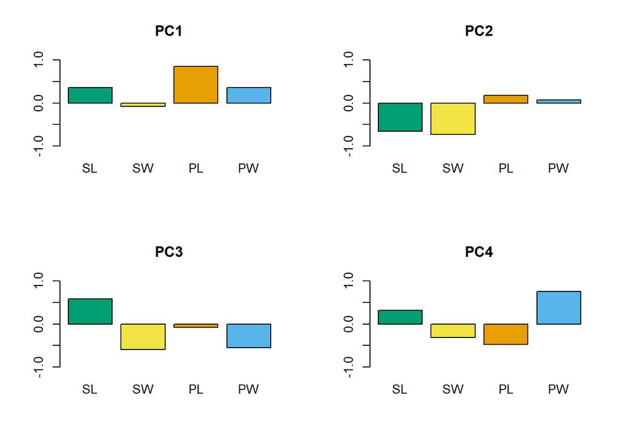

```r
abbrev <- c("SL", "SW", "PL", "PW")

par(mfrow = c(2, 2))

for (i in 1:ncol(pc1$rotation)) {
  barplot(pc1$rotation[, i],
    names.arg = abbrev, ylim = c(-1, 1), col = as.factor(abbrev),
    main = paste("PC", i, sep = "")
  )
}
```

### Plotting original vs transformed data

Where it is possible we can use symbols beside colors to distinguish between the classes. This is done with the `pch` argument.

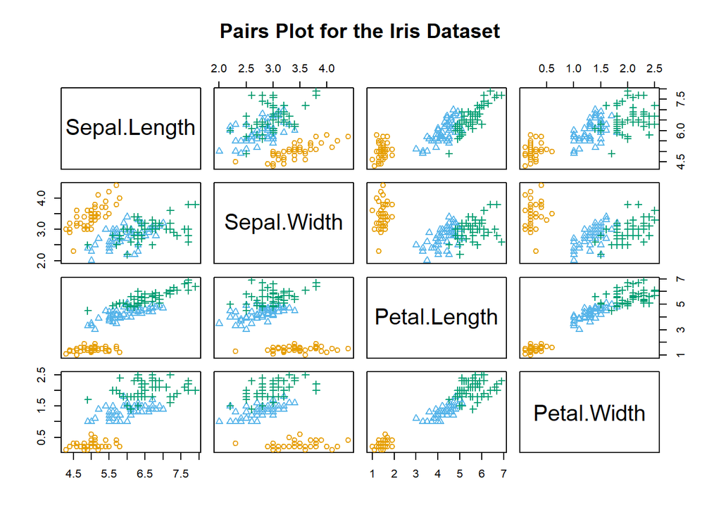

```r
pairs(iris[, 1:4],
  col = iris[, 5], pch = as.integer(iris[, 5]),
  main = "Pairs Plot for the Iris Dataset"
)
```

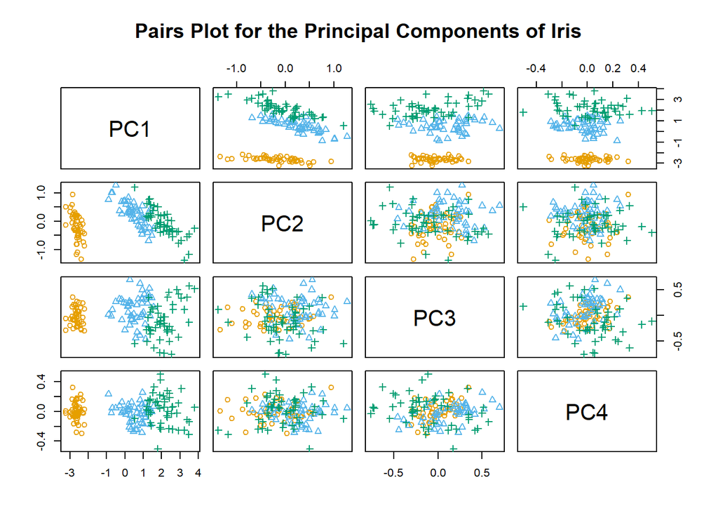

```r
pairs(pc1$x,
  col = iris[, 5], pch = as.integer(iris[, 5]),
  main = "Pairs Plot for the Principal Components of Iris"
)
```

### How well does the leading PC separate the classes?

We can use a box-and-whisker plot to see how well the leading PC separates the classes. The box is drawn from the first quartile `Q_1` to the third quartile `Q_3` and a horizontal line through the box denotes the median. The whiskers are drawn from `Q_1 - 1.5 * IQR` to `Q_3 + 1.5 * IQR` where `IQR = Q_3 - Q_1` is the interquartile range. Points outside this range are considered outliers and are plotted as individual points.

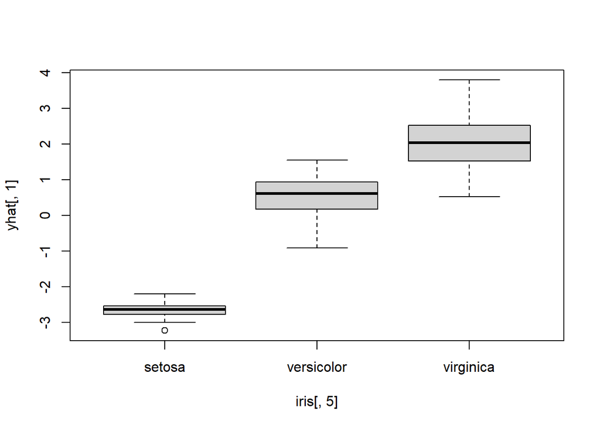

```r
boxplot(yhat[, 1] ~ iris[, 5])
```

We can see that Setosa is well separated from the other two species, but there is some overlap between Versicolor and Virginica. We can also see this from the pairs plot.

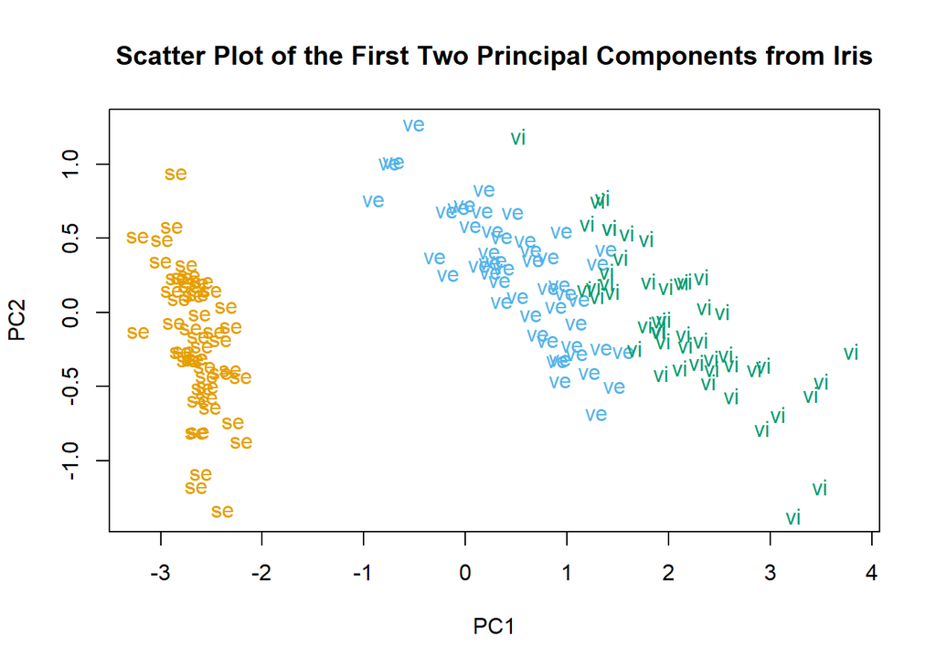

```r
plot(yhat[, 1], yhat[, 2],
  type = "n", xlab = "PC1", ylab = "PC2",
  main = "Scatter Plot of the First Two Principal Components from Iris"
)
text(yhat[, 1], yhat[, 2], labels = substr(iris[, 5], 1, 2), col = as.integer(iris[, 5]))
```

## PCA with scaled data

Recall $Var[aX] = a^2Var[X]$. Units matter! If something is in `cm` and something in `mm` it will not be good. If I change from `cm` to `mm`, I multiply by 10, but the variance multiplies by 100.

How to make unitless data?

$$x_{ij} = (x_{ij} -
\mu_j)/\sigma_j$$

The covariance matrix will be essentially replaced by the correlation matrix

```r
eigen(cor(iris[, 1:4]))
```

```
## eigen() decomposition
## $values
## [1] 2.91849782 0.91403047 0.14675688 0.02071484
##
## $vectors
##            [,1]        [,2]       [,3]       [,4]
## [1,]  0.5210659 -0.37741762  0.7195664  0.2612863
## [2,] -0.2693474 -0.92329566 -0.2443818 -0.1235096
## [3,]  0.5804131 -0.02449161 -0.1421264 -0.8014492
## [4,]  0.5648565 -0.06694199 -0.6342727  0.5235971
```

We can do this with `prcomp` by setting the `scale` argument to `TRUE`.

```r
pc2 <- prcomp(x, scale = TRUE)
summary(pc2)
```

```
## Importance of components:
##                           PC1    PC2     PC3     PC4
## Standard deviation     1.7084 0.9560 0.38309 0.14393
## Proportion of Variance 0.7296 0.2285 0.03669 0.00518
## Cumulative Proportion  0.7296 0.9581 0.99482 1.00000
```

```r
print(pc2)
```

```
## Standard deviations (1, .., p=4):
## [1] 1.7083611 0.9560494 0.3830886 0.1439265
##
## Rotation (n x k) = (4 x 4):
##                     PC1         PC2        PC3        PC4
## Sepal.Length  0.5210659 -0.37741762  0.7195664  0.2612863
## Sepal.Width  -0.2693474 -0.92329566 -0.2443818 -0.1235096
## Petal.Length  0.5804131 -0.02449161 -0.1421264 -0.8014492
## Petal.Width   0.5648565 -0.06694199 -0.6342727  0.5235971
```

The interpretation is very similar, but the coefficients are more balanced.

## 3 desitions when making PCA

1. which components to choose
2. how to interpret the output
3. how and if to scale the data

## Other useful graphs

### Scree plot

The scree plot shows the proportion of variance explained by each component. It is useful for deciding how many components to keep.

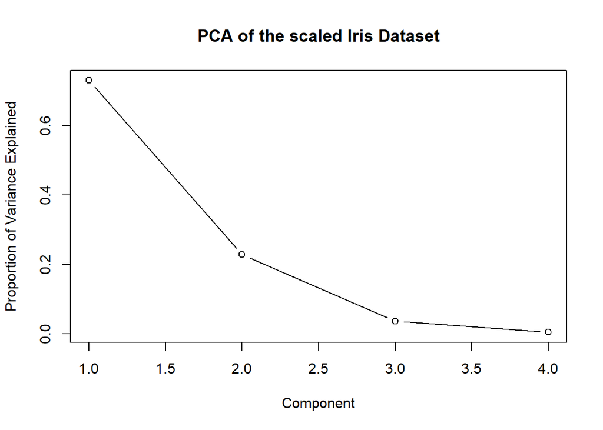

```r
plot(
  pc2$sdev^2 / sum(pc2$sdev^2),
  type = "b", main = "PCA of the scaled Iris Dataset",
  xlab = "Component", ylab = "Proportion of Variance Explained"
)
```

### GGally pairs plot

The `GGally` package contains a function called `ggpairs` which produces a more complicated version of the standard `pairs` plot. The lower triangle is the same as a basic pairs plot but the diagonal displays marginal density plots of every variable for each group and the upper triangle provides the overall and group-specific correlations for each pair of variables.

```r
library(GGally)
```

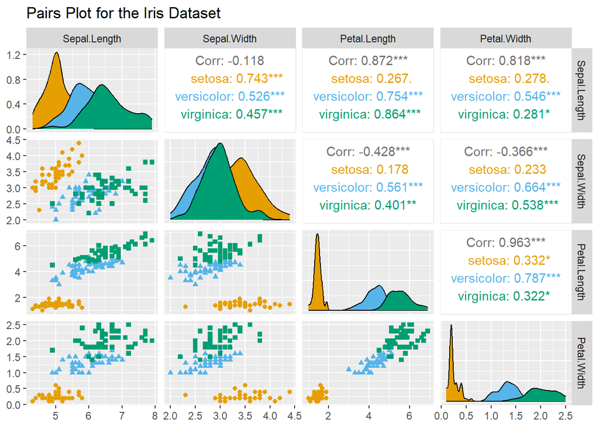

```r
ggpairs_iris <- ggpairs(
  data = iris, mapping = aes(colour = Species, shape = Species), columns = 1:4,
  title = "Pairs Plot for the Iris Dataset"
)
for (i in 1:4) {
  for (j in 1:4) {
    ggpairs_iris[i, j] <- (ggpairs_iris[i, j] + scale_colour_manual(values = mypal)
      + scale_fill_manual(values = mypal)
    )
  }
}
ggpairs_iris
```

### Biplot

A biplot is a scatterplot where each data point is represented by its scores along the principal components. The variables are represented by vectors pointing in the direction of increasing variance. The length of the vector represents the importance of the variable in the principal component.

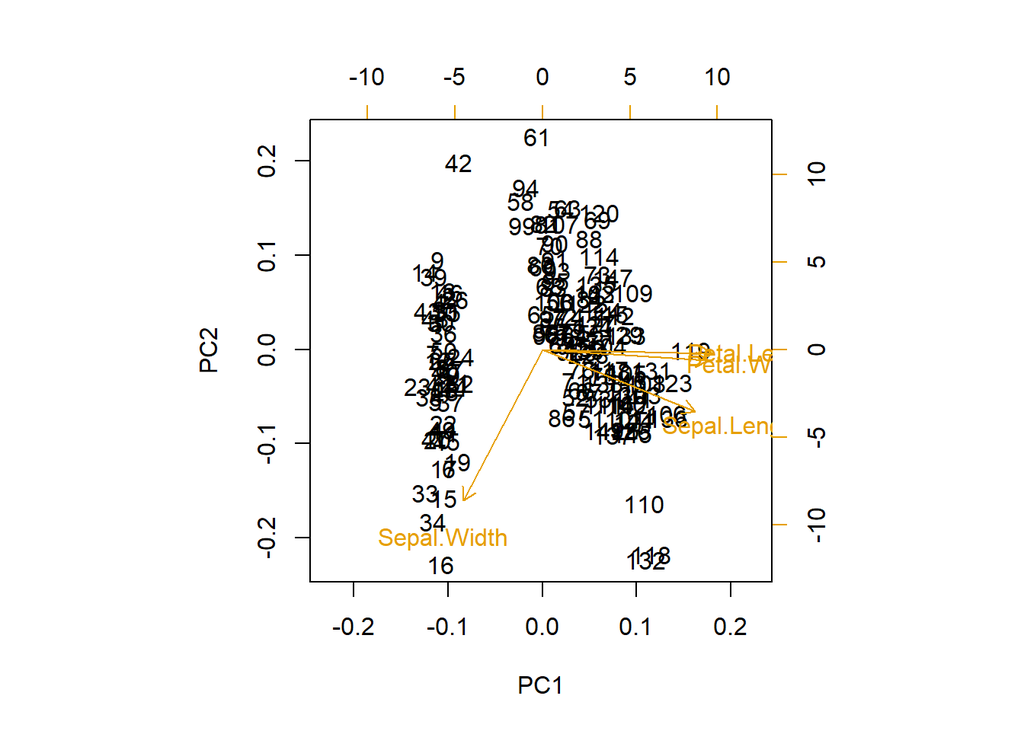

```r
biplot(pc2)
```